# Intra-Model Validation for Repeated Model Responses

# 4 Parse Repeated Responses

```r
parsed_long <- standardized %>%
  select(
    response_id,
    case_id,
    model_raw,
    model_clean,
    repeat_id,
    treatment_plan
  ) %>%
  mutate(parsed = map(treatment_plan, parse_one_response)) %>%
  unnest(parsed)

write_csv(
  parsed_long,
  file.path(output_dir, "intra_model_parsed_long.csv")
)

parsed_wide <- parsed_long %>%
  transmute(
    response_id,
    drug_class,
    mentioned,
    active = active_recommendation,
    start_add,
    continue,
    increase_intensify,
    reduce,
    stop_avoid = stop_or_avoid,
    conditional,
    caution_monitor,
    not_preferred,
    manual_review = manual_review_flag,
    component_mixed_action
  ) %>%
  pivot_wider(
    id_cols = response_id,
    names_from = drug_class,
    values_from = c(
      mentioned,
      active,
      start_add,
      continue,
      increase_intensify,
      reduce,
      stop_avoid,
      conditional,
      caution_monitor,
      not_preferred,
      manual_review,
      component_mixed_action
    ),
    names_glue = "{drug_class}_{.value}",
    values_fill = 0L
  ) %>%
  left_join(standardized, by = "response_id") %>%
  relocate(
    response_id,
    case_id,
    model_raw,
    model_clean,
    repeat_id,
    treatment_plan
  )

write_csv(
  parsed_wide,
  file.path(output_dir, "intra_model_parsed_wide.csv")
)

parser_qc <- tibble(
  metric = c(
    "parsed_long_rows",
    "parsed_wide_rows",
    "drug_classes",
    "expected_parsed_long_rows",
    "manual_review_flags"
  ),
  value = c(
    nrow(parsed_long),
    nrow(parsed_wide),
    n_distinct(parsed_long$drug_class),
    nrow(standardized) * nrow(drug_patterns),
    sum(parsed_long$manual_review_flag, na.rm = TRUE)
  )
)

parser_qc %>%
  kable(caption = "Parser QC") %>%
  kable_styling(full_width = FALSE)
```

Parser QC

| metric | value |
| --- | --- |
| parsed_long_rows | 15000 |
| parsed_wide_rows | 1500 |
| drug_classes | 10 |
| expected_parsed_long_rows | 15000 |
| manual_review_flags | 501 |

# 5 Structured Treatment Signatures

```r
signature_cols <- c(
  "mentioned",
  "active_recommendation",
  "start_add",
  "continue",
  "increase_intensify",
  "reduce",
  "stop_or_avoid",
  "conditional",
  "not_preferred",
  "manual_review_flag"
)

treatment_signatures <- parsed_long %>%
  mutate(
    signature_piece = str_c(
      drug_class,
      mentioned,
      active_recommendation,
      start_add,
      continue,
      increase_intensify,
      reduce,
      stop_or_avoid,
      conditional,
      not_preferred,
      manual_review_flag,
      sep = ":"
    )
  ) %>%
  arrange(response_id, drug_class) %>%
  summarise(
    treatment_signature = paste(signature_piece, collapse = "|"),
    n_drug_classes_mentioned = sum(mentioned, na.rm = TRUE),
    n_active_classes = sum(active_recommendation, na.rm = TRUE),
    n_stop_avoid_classes = sum(stop_or_avoid, na.rm = TRUE),
    n_manual_review_classes = sum(manual_review_flag, na.rm = TRUE),
    .by = c(response_id, case_id, model_clean, repeat_id)
  )

signature_counts <- treatment_signatures %>%
  count(model_clean, case_id, treatment_signature, name = "signature_count") %>%
  arrange(model_clean, case_id, desc(signature_count))

case_stability <- signature_counts %>%
  summarise(
    n_repeats = sum(signature_count),
    n_unique_signatures = n(),
    modal_signature_count = max(signature_count),
    variation_ratio = 1 - modal_signature_count / n_repeats,
    exact_match = as.integer(n_unique_signatures == 1),
    .by = c(model_clean, case_id)
  ) %>%
  arrange(model_clean, desc(variation_ratio), case_id)

model_summary <- case_stability %>%
  summarise(
    n_cases = n(),
    mean_variation_ratio = mean(variation_ratio),
    median_variation_ratio = median(variation_ratio),
    exact_match_cases = sum(exact_match),
    exact_match_rate = mean(exact_match),
    cases_with_any_variation = sum(variation_ratio > 0),
    max_variation_ratio = max(variation_ratio),
    .by = model_clean
  ) %>%
  arrange(mean_variation_ratio)

variation_ratio_distribution <- case_stability %>%
  count(model_clean, variation_ratio, name = "n_cases") %>%
  group_by(model_clean) %>%
  mutate(percent_cases = n_cases / sum(n_cases)) %>%
  ungroup() %>%
  arrange(model_clean, variation_ratio)

top_unstable_cases <- case_stability %>%
  group_by(model_clean) %>%
  slice_max(
    order_by = variation_ratio,
    n = 10,
    with_ties = FALSE
  ) %>%
  ungroup() %>%
  left_join(
    standardized %>%
      select(case_id, vignette_text) %>%
      distinct(),
    by = "case_id"
  )

write_csv(
  treatment_signatures,
  file.path(output_dir, "intra_model_treatment_signatures.csv")
)
write_csv(
  signature_counts,
  file.path(output_dir, "intra_model_signature_counts.csv")
)
write_csv(
  case_stability,
  file.path(output_dir, "intra_model_case_stability.csv")
)
write_csv(
  model_summary,
  file.path(output_dir, "intra_model_model_summary.csv")
)
write_csv(
  variation_ratio_distribution,
  file.path(output_dir, "intra_model_variation_ratio_distribution.csv")
)
write_csv(
  top_unstable_cases,
  file.path(output_dir, "intra_model_top_unstable_cases.csv")
)
```

```r
model_summary %>%
  mutate(
    mean_variation_ratio = round(mean_variation_ratio, 3),
    median_variation_ratio = round(median_variation_ratio, 3),
    exact_match_rate = percent(exact_match_rate, accuracy = 0.1)
  ) %>%
  kable(caption = "Model-level intra-model stability summary") %>%
  kable_styling(full_width = FALSE)
```

Model-level intra-model stability summary

| model_clean | n_cases | mean_variation_ratio | median_variation_ratio | exact_match_cases | exact_match_rate | cases_with_any_variation | max_variation_ratio |
| --- | --- | --- | --- | --- | --- | --- | --- |
| Claude Opus 4.6 | 100 | 0.274 | 0.2 | 38 | 38.0% | 62 | 0.8 |
| Claude Sonnet 4.6 | 100 | 0.538 | 0.6 | 4 | 4.0% | 96 | 0.8 |
| GPT-5.4 | 100 | 0.616 | 0.6 | 2 | 2.0% | 98 | 0.8 |

```r
variation_ratio_distribution %>%
  mutate(percent_cases = percent(percent_cases, accuracy = 0.1)) %>%
  kable(caption = "Variation ratio distribution by model") %>%
  kable_styling(full_width = FALSE)
```

Variation ratio distribution by model

| model_clean | variation_ratio | n_cases | percent_cases |
| --- | --- | --- | --- |
| Claude Opus 4.6 | 0.0 | 38 | 38.0% |
| Claude Opus 4.6 | 0.2 | 22 | 22.0% |
| Claude Opus 4.6 | 0.4 | 13 | 13.0% |
| Claude Opus 4.6 | 0.6 | 19 | 19.0% |
| Claude Opus 4.6 | 0.8 | 8 | 8.0% |
| Claude Sonnet 4.6 | 0.0 | 4 | 4.0% |
| Claude Sonnet 4.6 | 0.2 | 14 | 14.0% |
| Claude Sonnet 4.6 | 0.4 | 18 | 18.0% |
| Claude Sonnet 4.6 | 0.6 | 37 | 37.0% |
| Claude Sonnet 4.6 | 0.8 | 27 | 27.0% |
| GPT-5.4 | 0.0 | 2 | 2.0% |
| GPT-5.4 | 0.2 | 6 | 6.0% |
| GPT-5.4 | 0.4 | 16 | 16.0% |
| GPT-5.4 | 0.6 | 34 | 34.0% |
| GPT-5.4 | 0.8 | 42 | 42.0% |

# 6 Krippendorff’s Alpha

Krippendorff’s alpha is used here as a formal agreement statistic for repeated model outputs. For each model, the five repeated responses are treated like five raters assigning a structured treatment signature to each case. Because the signature is a categorical plan identity, this workflow uses nominal alpha.

```r
krippendorff_alpha_nominal <- function(x) {
  x <- as.matrix(x)

  unit_counts <- apply(x, 1, function(row_values) {
    row_values <- row_values[!is.na(row_values) & row_values != ""]

    if (length(row_values) < 2) {
      return(NA_real_)
    }

    tab <- table(row_values)
    n_unit <- sum(tab)

    sum(tab * (n_unit - tab)) / (n_unit * (n_unit - 1))
  })

  observed_disagreement <- mean(unit_counts, na.rm = TRUE)

  all_values <- as.vector(x)
  all_values <- all_values[!is.na(all_values) & all_values != ""]
  pooled_tab <- table(all_values)
  pooled_n <- sum(pooled_tab)

  expected_disagreement <- sum(pooled_tab * (pooled_n - pooled_tab)) /
    (pooled_n * (pooled_n - 1))

  if (is.na(expected_disagreement) || expected_disagreement == 0) {
    return(NA_real_)
  }

  1 - observed_disagreement / expected_disagreement
}

alpha_by_model <- treatment_signatures %>%
  select(model_clean, case_id, repeat_id, treatment_signature) %>%
  mutate(repeat_id = paste0("repeat_", repeat_id)) %>%
  pivot_wider(
    names_from = repeat_id,
    values_from = treatment_signature
  ) %>%
  group_by(model_clean) %>%
  group_modify(~ {
    signature_matrix <- .x %>%
      select(starts_with("repeat_")) %>%
      as.matrix()

    tibble(
      krippendorff_alpha = krippendorff_alpha_nominal(signature_matrix),
      n_cases = nrow(.x),
      n_repeats = ncol(signature_matrix)
    )
  }) %>%
  ungroup() %>%
  mutate(
    interpretation = case_when(
      is.na(krippendorff_alpha) ~ "Not estimable",
      krippendorff_alpha >= 0.80 ~ "Strong agreement",
      krippendorff_alpha >= 0.67 ~ "Tentative agreement",
      krippendorff_alpha > 0 ~ "Low agreement",
      TRUE ~ "No better than chance"
    )
  ) %>%
  arrange(desc(krippendorff_alpha))

model_summary <- model_summary %>%
  left_join(
    alpha_by_model %>%
      select(model_clean, krippendorff_alpha, alpha_interpretation = interpretation),
    by = "model_clean"
  )

write_csv(
  alpha_by_model,
  file.path(output_dir, "intra_model_krippendorff_alpha.csv")
)
write_csv(
  model_summary,
  file.path(output_dir, "intra_model_model_summary.csv")
)

alpha_by_model %>%
  mutate(
    krippendorff_alpha = round(krippendorff_alpha, 3)
  ) %>%
  kable(caption = "Krippendorff's alpha for structured treatment signatures") %>%
  kable_styling(full_width = FALSE)
```

Krippendorff’s alpha for structured treatment signatures

| model_clean | krippendorff_alpha | n_cases | n_repeats | interpretation |
| --- | --- | --- | --- | --- |
| Claude Opus 4.6 | 0.575 | 100 | 5 | Low agreement |
| Claude Sonnet 4.6 | 0.220 | 100 | 5 | Low agreement |
| GPT-5.4 | 0.142 | 100 | 5 | Low agreement |

Higher Krippendorff’s alpha indicates that the model repeatedly assigned the same structured treatment signature to the same case more often than expected by chance. Values near 1 indicate strong intra-model consistency. Values near 0 indicate agreement no better than chance after accounting for the overall distribution of treatment signatures.

# 7 Alpha Sensitivity Analysis

The full treatment signature is intentionally strict because it includes rationale-level mentions, stop/avoid language, conditional alternatives, and manual-review flags. To separate core prescribing consistency from broader response-style consistency, this section recalculates Krippendorff’s alpha using progressively stricter signature definitions.

```r
make_response_signature <- function(data, signature_variables) {
  data %>%
    mutate(
      signature_piece = pmap_chr(
        select(., drug_class, all_of(signature_variables)),
        ~ paste(c(...), collapse = ":")
      )
    ) %>%
    arrange(response_id, drug_class) %>%
    summarise(
      treatment_signature = paste(signature_piece, collapse = "|"),
      .by = c(model_clean, case_id, repeat_id, response_id)
    )
}

calculate_alpha_for_signature <- function(signature_data) {
  signature_data %>%
    select(model_clean, case_id, repeat_id, treatment_signature) %>%
    mutate(repeat_id = paste0("repeat_", repeat_id)) %>%
    pivot_wider(
      names_from = repeat_id,
      values_from = treatment_signature
    ) %>%
    group_by(model_clean) %>%
    group_modify(~ {
      signature_matrix <- .x %>%
        select(starts_with("repeat_")) %>%
        as.matrix()

      tibble(alpha = krippendorff_alpha_nominal(signature_matrix))
    }) %>%
    ungroup()
}

alpha_sensitivity_specs <- list(
  "Active only alpha" = c("active_recommendation"),
  "Active + stop/avoid alpha" = c(
    "active_recommendation",
    "stop_or_avoid"
  ),
  "Full signature alpha" = signature_cols
)

alpha_sensitivity_long <- imap_dfr(
  alpha_sensitivity_specs,
  function(signature_variables, metric_definition) {
    make_response_signature(parsed_long, signature_variables) %>%
      calculate_alpha_for_signature() %>%
      mutate(metric_definition = metric_definition)
  }
) %>%
  mutate(
    metric_definition = factor(
      metric_definition,
      levels = names(alpha_sensitivity_specs)
    )
  ) %>%
  arrange(metric_definition, model_clean)

alpha_sensitivity_wide <- alpha_sensitivity_long %>%
  mutate(
    model_label = case_when(
      model_clean == "Claude Opus 4.6" ~ "Claude Opus",
      model_clean == "Claude Sonnet 4.6" ~ "Claude Sonnet",
      model_clean == "GPT-5.4" ~ "GPT-5.4",
      TRUE ~ model_clean
    ),
    alpha = round(alpha, 3)
  ) %>%
  select(metric_definition, model_label, alpha) %>%
  pivot_wider(
    names_from = model_label,
    values_from = alpha
  ) %>%
  arrange(metric_definition)

write_csv(
  alpha_sensitivity_long,
  file.path(output_dir, "intra_model_alpha_sensitivity_long.csv")
)
write_csv(
  alpha_sensitivity_wide,
  file.path(output_dir, "intra_model_alpha_sensitivity_table.csv")
)

alpha_sensitivity_wide %>%
  kable(caption = "Krippendorff's alpha sensitivity analysis") %>%
  kable_styling(full_width = FALSE)
```

Krippendorff’s alpha sensitivity analysis

| metric_definition | Claude Opus | Claude Sonnet | GPT-5.4 |
| --- | --- | --- | --- |
| Active only alpha | 0.962 | 0.940 | 0.795 |
| Active + stop/avoid alpha | 0.859 | 0.673 | 0.493 |
| Full signature alpha | 0.575 | 0.220 | 0.142 |

The sensitivity results help interpret the low full-signature alpha values. Active medication recommendations are substantially more stable than the full signature, indicating that much of the strict-signature variation comes from secondary language about stopping, avoiding, considering, or mentioning drugs in the rationale.

# 8 Medication Column Dose-Level Consistency

The `medication` column is a more compact representation of the final treatment plan than the full `treatment_plan` text. This section parses medication names, actions, and dose/frequency text from that column to estimate consistency in the final prescription-style output.

```r
medication_name_patterns <- tibble::tribble(
  ~medication_name, ~medication_regex,
  "metformin", "\\bmetformin\\b",
  "sitagliptin", "\\bsitagliptin\\b",
  "linagliptin", "\\blinagliptin\\b",
  "empagliflozin", "\\bempagliflozin\\b",
  "dapagliflozin", "\\bdapagliflozin\\b",
  "canagliflozin", "\\bcanagliflozin\\b",
  "semaglutide", "\\bsemaglutide\\b",
  "liraglutide", "\\bliraglutide\\b",
  "dulaglutide", "\\bdulaglutide\\b",
  "tirzepatide", "\\btirzepatide\\b",
  "insulin glargine", "\\binsulin glargine\\b|\\bglargine\\b",
  "insulin aspart", "\\binsulin aspart\\b|\\baspart\\b",
  "insulin lispro", "\\binsulin lispro\\b|\\blispro\\b",
  "insulin degludec", "\\binsulin degludec\\b|\\bdegludec\\b",
  "nph insulin", "\\bnph\\b",
  "glipizide", "\\bglipizide\\b",
  "glimepiride", "\\bglimepiride\\b",
  "glyburide", "\\bglyburide\\b",
  "pioglitazone", "\\bpioglitazone\\b"
)

normalize_medication_text <- function(x) {
  x %>%
    replace_na("") %>%
    str_replace_all("<br\\s*/?>", "\n") %>%
    str_replace_all("&nbsp;", " ") %>%
    str_replace_all("[\u2022]", "\n") %>%
    str_replace_all("\\r", "\n")
}

split_medication_lines <- function(x) {
  normalize_medication_text(x) %>%
    str_split("\\n") %>%
    .[[1]] %>%
    str_squish() %>%
    purrr::discard(~ .x == "")
}

detect_medication_action <- function(line) {
  line_lower <- str_to_lower(line)

  case_when(
    str_detect(line_lower, "\\b(stop|discontinue|hold|avoid)\\b") ~ "stop",
    str_detect(line_lower, "\\b(continue|maintain|keep)\\b") ~ "continue",
    str_detect(line_lower, "\\b(start|add|initiate|begin|new)\\b") ~ "start",
    str_detect(line_lower, "\\b(change|switch|modify|adjust)\\b") ~ "change",
    str_detect(line_lower, "\\b(reduce|decrease|lower|down-titrate|downtitrate)\\b") ~ "reduce",
    str_detect(line_lower, "\\b(increase|raise|intensify|titrate up|uptitrate)\\b") ~ "increase",
    TRUE ~ "unknown"
  )
}

extract_medication_name <- function(line) {
  matched <- medication_name_patterns %>%
    filter(str_detect(line, regex(medication_regex, ignore_case = TRUE))) %>%
    pull(medication_name)

  if (length(matched) > 0) {
    return(matched[1])
  }

  line %>%
    str_to_lower() %>%
    str_remove("^\\s*(start|add|initiate|begin|new|continue|maintain|keep|stop|discontinue|hold|avoid|change|switch|modify|adjust|reduce|decrease|lower|increase|raise|intensify)\\s+") %>%
    str_remove("\\s+(to|at)?\\s*\\d.*$") %>%
    str_squish()
}

normalize_dose_text <- function(line, medication_name, action) {
  if (action == "stop") {
    return("")
  }

  dose <- line %>%
    str_to_lower() %>%
    str_remove("^\\s*(start|add|initiate|begin|new|continue|maintain|keep|change|switch|modify|adjust|reduce|decrease|lower|increase|raise|intensify)\\s+") %>%
    str_remove(regex(medication_name, ignore_case = TRUE)) %>%
    str_remove("^\\s*(to|at|-|:)\\s*") %>%
    str_replace_all("\\bby mouth\\b|\\bpo\\b", "") %>%
    str_replace_all("\\bsubcutaneous injection\\b|\\bsubcutaneously\\b|\\bsubcutaneous\\b", "sq") %>%
    str_replace_all("\\bonce daily\\b", "daily") %>%
    str_replace_all("\\btwice daily\\b", "bid") %>%
    str_replace_all("\\bthree times daily\\b", "tid") %>%
    str_replace_all("\\bonce weekly\\b", "weekly") %>%
    str_replace_all("\\s+", " ") %>%
    str_squish()

  dose
}

parse_medication_column_one_response <- function(medication_text) {
  lines <- split_medication_lines(medication_text)

  if (length(lines) == 0) {
    return(tibble(
      medication_name = character(),
      medication_action = character(),
      dose_frequency = character(),
      source_line = character()
    ))
  }

  map_dfr(lines, function(line) {
    action <- detect_medication_action(line)
    med_name <- extract_medication_name(line)
    dose_text <- normalize_dose_text(line, med_name, action)

    tibble(
      medication_name = med_name,
      medication_action = action,
      dose_frequency = dose_text,
      source_line = line
    )
  }) %>%
    filter(!is.na(medication_name), medication_name != "")
}

medication_parsed_long <- standardized %>%
  select(response_id, case_id, model_clean, repeat_id, medication) %>%
  mutate(parsed_medication = map(medication, parse_medication_column_one_response)) %>%
  unnest(parsed_medication) %>%
  mutate(
    medication_name = str_squish(str_to_lower(medication_name)),
    medication_action = str_squish(str_to_lower(medication_action)),
    dose_frequency = str_squish(str_to_lower(dose_frequency))
  ) %>%
  arrange(model_clean, case_id, repeat_id, medication_name)

make_medication_column_signature <- function(data, signature_level) {
  data %>%
    mutate(
      signature_piece = case_when(
        signature_level == "Medication-name alpha" ~ medication_name,
        signature_level == "Medication-action alpha" ~ str_c(
          medication_action,
          medication_name,
          sep = ":"
        ),
        signature_level == "Medication-action-dose alpha" ~ str_c(
          medication_action,
          medication_name,
          dose_frequency,
          sep = ":"
        ),
        TRUE ~ medication_name
      )
    ) %>%
    arrange(response_id, signature_piece) %>%
    summarise(
      medication_signature = paste(unique(signature_piece), collapse = "|"),
      n_medications = n_distinct(medication_name),
      .by = c(model_clean, case_id, repeat_id, response_id)
    )
}

medication_alpha_specs <- c(
  "Medication-name alpha",
  "Medication-action alpha",
  "Medication-action-dose alpha"
)

medication_alpha_long <- map_dfr(
  medication_alpha_specs,
  function(metric_definition) {
    make_medication_column_signature(
      medication_parsed_long,
      metric_definition
    ) %>%
      select(model_clean, case_id, repeat_id, medication_signature) %>%
      mutate(repeat_id = paste0("repeat_", repeat_id)) %>%
      pivot_wider(
        names_from = repeat_id,
        values_from = medication_signature
      ) %>%
      group_by(model_clean) %>%
      group_modify(~ {
        signature_matrix <- .x %>%
          select(starts_with("repeat_")) %>%
          as.matrix()

        tibble(alpha = krippendorff_alpha_nominal(signature_matrix))
      }) %>%
      ungroup() %>%
      mutate(metric_definition = metric_definition)
  }
) %>%
  mutate(
    metric_definition = factor(
      metric_definition,
      levels = medication_alpha_specs
    )
  ) %>%
  arrange(metric_definition, model_clean)

medication_alpha_wide <- medication_alpha_long %>%
  mutate(
    model_label = case_when(
      model_clean == "Claude Opus 4.6" ~ "Claude Opus",
      model_clean == "Claude Sonnet 4.6" ~ "Claude Sonnet",
      model_clean == "GPT-5.4" ~ "GPT-5.4",
      TRUE ~ model_clean
    ),
    alpha = round(alpha, 3)
  ) %>%
  select(metric_definition, model_label, alpha) %>%
  pivot_wider(
    names_from = model_label,
    values_from = alpha
  ) %>%
  arrange(metric_definition)

medication_dose_signatures <- make_medication_column_signature(
  medication_parsed_long,
  "Medication-action-dose alpha"
)

medication_dose_case_stability <- medication_dose_signatures %>%
  count(model_clean, case_id, medication_signature, name = "signature_count") %>%
  summarise(
    n_repeats = sum(signature_count),
    n_unique_medication_signatures = n(),
    modal_signature_count = max(signature_count),
    medication_dose_variation_ratio = 1 - modal_signature_count / n_repeats,
    .by = c(model_clean, case_id)
  ) %>%
  arrange(model_clean, desc(medication_dose_variation_ratio), case_id)

top_medication_dose_disagreement_cases <-
  medication_dose_case_stability %>%
  group_by(model_clean) %>%
  slice_max(
    order_by = medication_dose_variation_ratio,
    n = 10,
    with_ties = FALSE
  ) %>%
  ungroup()

write_csv(
  medication_parsed_long,
  file.path(output_dir, "intra_model_medication_column_parsed_long.csv")
)
write_csv(
  medication_alpha_long,
  file.path(output_dir, "intra_model_medication_column_alpha_long.csv")
)
write_csv(
  medication_alpha_wide,
  file.path(output_dir, "intra_model_medication_column_alpha_table.csv")
)
write_csv(
  medication_dose_case_stability,
  file.path(output_dir, "intra_model_medication_dose_case_stability.csv")
)
write_csv(
  top_medication_dose_disagreement_cases,
  file.path(output_dir, "intra_model_top_medication_dose_disagreement_cases.csv")
)

medication_alpha_wide %>%
  kable(caption = "Medication-column Krippendorff's alpha") %>%
  kable_styling(full_width = FALSE)
```

Medication-column Krippendorff’s alpha

| metric_definition | Claude Opus | Claude Sonnet | GPT-5.4 |
| --- | --- | --- | --- |
| Medication-name alpha | 0.952 | 0.935 | 0.798 |
| Medication-action alpha | 0.950 | 0.934 | 0.782 |
| Medication-action-dose alpha | 0.840 | 0.747 | 0.647 |

```r
top_medication_dose_disagreement_cases %>%
  kable(caption = "Top medication action-dose disagreement cases") %>%
  kable_styling(full_width = FALSE)
```

Top medication action-dose disagreement cases

| model_clean | case_id | n_repeats | n_unique_medication_signatures | modal_signature_count | medication_dose_variation_ratio |
| --- | --- | --- | --- | --- | --- |
| Claude Opus 4.6 | DM024 | 5 | 3 | 2 | 0.6 |
| Claude Opus 4.6 | DM063 | 5 | 3 | 2 | 0.6 |
| Claude Opus 4.6 | DM116 | 5 | 3 | 2 | 0.6 |
| Claude Opus 4.6 | DM021 | 5 | 3 | 3 | 0.4 |
| Claude Opus 4.6 | DM022 | 5 | 2 | 3 | 0.4 |
| Claude Opus 4.6 | DM026(1) | 5 | 2 | 3 | 0.4 |
| Claude Opus 4.6 | DM027 | 5 | 2 | 3 | 0.4 |
| Claude Opus 4.6 | DM034 | 5 | 2 | 3 | 0.4 |
| Claude Opus 4.6 | DM040 | 5 | 2 | 3 | 0.4 |
| Claude Opus 4.6 | DM042 | 5 | 2 | 3 | 0.4 |
| Claude Sonnet 4.6 | DM034 | 5 | 4 | 2 | 0.6 |
| Claude Sonnet 4.6 | DM038 | 5 | 3 | 2 | 0.6 |
| Claude Sonnet 4.6 | DM065 | 5 | 3 | 2 | 0.6 |
| Claude Sonnet 4.6 | DM080 | 5 | 4 | 2 | 0.6 |
| Claude Sonnet 4.6 | DM104 | 5 | 4 | 2 | 0.6 |
| Claude Sonnet 4.6 | DM113 | 5 | 3 | 2 | 0.6 |
| Claude Sonnet 4.6 | DM114 | 5 | 4 | 2 | 0.6 |
| Claude Sonnet 4.6 | DM120 | 5 | 3 | 2 | 0.6 |
| Claude Sonnet 4.6 | DM024 | 5 | 2 | 3 | 0.4 |
| Claude Sonnet 4.6 | DM028 | 5 | 3 | 3 | 0.4 |
| GPT-5.4 | DM121 | 5 | 5 | 1 | 0.8 |
| GPT-5.4 | DM021 | 5 | 4 | 2 | 0.6 |
| GPT-5.4 | DM026(3) | 5 | 3 | 2 | 0.6 |
| GPT-5.4 | DM028 | 5 | 4 | 2 | 0.6 |
| GPT-5.4 | DM031 | 5 | 4 | 2 | 0.6 |
| GPT-5.4 | DM033 | 5 | 4 | 2 | 0.6 |
| GPT-5.4 | DM036 | 5 | 4 | 2 | 0.6 |
| GPT-5.4 | DM043 | 5 | 3 | 2 | 0.6 |
| GPT-5.4 | DM048 | 5 | 4 | 2 | 0.6 |
| GPT-5.4 | DM060 | 5 | 3 | 2 | 0.6 |

Medication-column alpha is a dose-level sensitivity analysis focused on the final prescription-style output. Medication-name alpha evaluates whether the same drugs are listed; medication-action alpha adds start/stop/continue/change decisions; medication-action-dose alpha additionally includes normalized dose and frequency text.

# 9 Secondary Agreement Metrics

```r
medication_class_agreement <- parsed_long %>%
  summarise(
    repeat_count = n(),
    mentioned_agreement = as.integer(n_distinct(mentioned) == 1),
    active_agreement = as.integer(n_distinct(active_recommendation) == 1),
    stop_avoid_agreement = as.integer(n_distinct(stop_or_avoid) == 1),
    any_mentioned = max(mentioned, na.rm = TRUE),
    any_active = max(active_recommendation, na.rm = TRUE),
    any_stop_avoid = max(stop_or_avoid, na.rm = TRUE),
    .by = c(model_clean, case_id, drug_class)
  ) %>%
  summarise(
    n_case_drug_pairs = n(),
    mentioned_agreement_rate = mean(mentioned_agreement),
    active_agreement_rate = mean(active_agreement),
    stop_avoid_agreement_rate = mean(stop_avoid_agreement),
    n_pairs_ever_mentioned = sum(any_mentioned),
    n_pairs_ever_active = sum(any_active),
    n_pairs_ever_stop_avoid = sum(any_stop_avoid),
    .by = c(model_clean, drug_class)
  ) %>%
  arrange(model_clean, drug_class)

action_level_agreement <- parsed_long %>%
  pivot_longer(
    cols = all_of(signature_cols),
    names_to = "action_indicator",
    values_to = "value"
  ) %>%
  summarise(
    agreement = as.integer(n_distinct(value) == 1),
    ever_present = max(value, na.rm = TRUE),
    .by = c(model_clean, case_id, drug_class, action_indicator)
  ) %>%
  summarise(
    n_case_drug_action_pairs = n(),
    agreement_rate = mean(agreement),
    n_pairs_ever_present = sum(ever_present),
    .by = c(model_clean, action_indicator)
  ) %>%
  arrange(model_clean, action_indicator)

manual_review_burden <- parsed_long %>%
  summarise(
    manual_review_classes = sum(manual_review_flag, na.rm = TRUE),
    any_manual_review = as.integer(any(manual_review_flag == 1)),
    .by = c(model_clean, response_id, case_id, repeat_id)
  ) %>%
  summarise(
    n_responses = n(),
    responses_with_manual_review = sum(any_manual_review),
    response_manual_review_rate = mean(any_manual_review),
    total_manual_review_classes = sum(manual_review_classes),
    .by = model_clean
  ) %>%
  arrange(desc(response_manual_review_rate))

write_csv(
  medication_class_agreement,
  file.path(output_dir, "intra_model_medication_class_agreement.csv")
)
write_csv(
  action_level_agreement,
  file.path(output_dir, "intra_model_action_level_agreement.csv")
)
write_csv(
  manual_review_burden,
  file.path(output_dir, "intra_model_manual_review_burden.csv")
)

medication_class_agreement %>%
  mutate(
    mentioned_agreement_rate = percent(mentioned_agreement_rate, accuracy = 0.1),
    active_agreement_rate = percent(active_agreement_rate, accuracy = 0.1),
    stop_avoid_agreement_rate = percent(stop_avoid_agreement_rate, accuracy = 0.1)
  ) %>%
  kable(caption = "Medication-class agreement by model") %>%
  kable_styling(full_width = FALSE)
```

Medication-class agreement by model

| model_clean | drug_class | n_case_drug_pairs | mentioned_agreement_rate | active_agreement_rate | stop_avoid_agreement_rate | n_pairs_ever_mentioned | n_pairs_ever_active | n_pairs_ever_stop_avoid |
| --- | --- | --- | --- | --- | --- | --- | --- | --- |
| Claude Opus 4.6 | basal_insulin | 100 | 94.0% | 96.0% | 99.0% | 30 | 28 | 1 |
| Claude Opus 4.6 | dpp4i | 100 | 99.0% | 99.0% | 100.0% | 7 | 5 | 2 |
| Claude Opus 4.6 | gip_glp1 | 100 | 100.0% | 100.0% | 100.0% | 7 | 7 | 0 |
| Claude Opus 4.6 | glp1 | 100 | 88.0% | 97.0% | 95.0% | 82 | 58 | 5 |
| Claude Opus 4.6 | insulin_any | 100 | 79.0% | 96.0% | 92.0% | 54 | 28 | 10 |
| Claude Opus 4.6 | metformin | 100 | 94.0% | 98.0% | 93.0% | 90 | 67 | 24 |
| Claude Opus 4.6 | prandial_insulin | 100 | 100.0% | 100.0% | 100.0% | 3 | 2 | 1 |
| Claude Opus 4.6 | sglt2i | 100 | 92.0% | 98.0% | 95.0% | 86 | 58 | 13 |
| Claude Opus 4.6 | sulfonylurea | 100 | 99.0% | 100.0% | 99.0% | 2 | 0 | 2 |
| Claude Opus 4.6 | tzd | 100 | 100.0% | 100.0% | 100.0% | 4 | 4 | 0 |
| Claude Sonnet 4.6 | basal_insulin | 100 | 95.0% | 99.0% | 100.0% | 35 | 31 | 0 |
| Claude Sonnet 4.6 | dpp4i | 100 | 88.0% | 98.0% | 97.0% | 18 | 6 | 4 |
| Claude Sonnet 4.6 | gip_glp1 | 100 | 99.0% | 99.0% | 100.0% | 8 | 8 | 0 |
| Claude Sonnet 4.6 | glp1 | 100 | 80.0% | 96.0% | 79.0% | 99 | 61 | 21 |
| Claude Sonnet 4.6 | insulin_any | 100 | 59.0% | 99.0% | 85.0% | 78 | 31 | 18 |
| Claude Sonnet 4.6 | metformin | 100 | 94.0% | 97.0% | 91.0% | 100 | 61 | 36 |
| Claude Sonnet 4.6 | prandial_insulin | 100 | 95.0% | 98.0% | 99.0% | 8 | 3 | 3 |
| Claude Sonnet 4.6 | sglt2i | 100 | 80.0% | 99.0% | 73.0% | 96 | 37 | 33 |
| Claude Sonnet 4.6 | sulfonylurea | 100 | 95.0% | 99.0% | 97.0% | 6 | 1 | 4 |
| Claude Sonnet 4.6 | tzd | 100 | 98.0% | 100.0% | 98.0% | 3 | 1 | 2 |
| GPT-5.4 | basal_insulin | 100 | 90.0% | 90.0% | 100.0% | 21 | 21 | 0 |
| GPT-5.4 | dpp4i | 100 | 92.0% | 92.0% | 98.0% | 13 | 11 | 3 |
| GPT-5.4 | gip_glp1 | 100 | 100.0% | 100.0% | 100.0% | 7 | 7 | 0 |
| GPT-5.4 | glp1 | 100 | 74.0% | 85.0% | 91.0% | 62 | 47 | 10 |
| GPT-5.4 | insulin_any | 100 | 49.0% | 90.0% | 43.0% | 97 | 21 | 59 |
| GPT-5.4 | metformin | 100 | 88.0% | 95.0% | 80.0% | 96 | 68 | 22 |
| GPT-5.4 | prandial_insulin | 100 | 96.0% | 100.0% | 96.0% | 6 | 1 | 5 |
| GPT-5.4 | sglt2i | 100 | 77.0% | 87.0% | 85.0% | 82 | 59 | 17 |
| GPT-5.4 | sulfonylurea | 100 | 76.0% | 98.0% | 92.0% | 26 | 3 | 9 |
| GPT-5.4 | tzd | 100 | 92.0% | 100.0% | 93.0% | 8 | 0 | 7 |

```r
manual_review_burden %>%
  mutate(
    response_manual_review_rate = percent(
      response_manual_review_rate,
      accuracy = 0.1
    )
  ) %>%
  kable(caption = "Manual-review burden by model") %>%
  kable_styling(full_width = FALSE)
```

Manual-review burden by model

| model_clean | n_responses | responses_with_manual_review | response_manual_review_rate | total_manual_review_classes |
| --- | --- | --- | --- | --- |
| GPT-5.4 | 500 | 147 | 29.4% | 199 |
| Claude Sonnet 4.6 | 500 | 127 | 25.4% | 160 |
| Claude Opus 4.6 | 500 | 115 | 23.0% | 142 |

# 10 Targeted Review of Unstable and Parser-Flagged Cases

This section focuses on the strictest instability pattern: cases with `variation_ratio == 0.8`, where all five repeated responses produced different full treatment signatures. Within those cases, we specifically inspect parser flags from `free_text_rationale`, because these flags usually come from rationale-level mentions rather than the medication table itself.

```r
max_unstable_cases <- case_stability %>%
  filter(variation_ratio == 0.8)

max_unstable_case_counts <- max_unstable_cases %>%
  count(model_clean, name = "n_max_unstable_cases") %>%
  arrange(desc(n_max_unstable_cases))

parsed_with_unstable_flag <- parsed_long %>%
  left_join(
    max_unstable_cases %>%
      select(model_clean, case_id, variation_ratio),
    by = c("model_clean", "case_id")
  ) %>%
  mutate(
    is_max_unstable_case = !is.na(variation_ratio)
  )

targeted_review_rows <- parsed_with_unstable_flag %>%
  filter(
    is_max_unstable_case,
    manual_review_flag == 1,
    source_used == "free_text_rationale"
  ) %>%
  select(
    model_clean,
    case_id,
    repeat_id,
    response_id,
    drug_class,
    source_used,
    mentioned,
    active_recommendation,
    stop_or_avoid,
    conditional,
    not_preferred,
    unclear,
    manual_review_flag,
    example_text
  ) %>%
  arrange(model_clean, case_id, repeat_id, drug_class)

manual_review_rate_by_instability <- parsed_with_unstable_flag %>%
  summarise(
    any_manual_review = as.integer(any(manual_review_flag == 1)),
    .by = c(model_clean, case_id, repeat_id, is_max_unstable_case)
  ) %>%
  summarise(
    n_responses = n(),
    responses_with_manual_review = sum(any_manual_review),
    manual_review_response_rate = mean(any_manual_review),
    .by = c(model_clean, is_max_unstable_case)
  ) %>%
  arrange(model_clean, desc(is_max_unstable_case))

manual_review_by_model_drug <- parsed_long %>%
  summarise(
    manual_review_flags = sum(manual_review_flag, na.rm = TRUE),
    .by = c(model_clean, drug_class)
  ) %>%
  arrange(model_clean, desc(manual_review_flags))

manual_review_by_model_source <- parsed_long %>%
  filter(!is.na(source_used)) %>%
  summarise(
    manual_review_flags = sum(manual_review_flag, na.rm = TRUE),
    .by = c(model_clean, source_used)
  ) %>%
  arrange(model_clean, desc(manual_review_flags))

active_treatment_combinations <- parsed_long %>%
  semi_join(
    top_unstable_cases,
    by = c("model_clean", "case_id")
  ) %>%
  filter(active_recommendation == 1) %>%
  summarise(
    active_drug_classes = paste(sort(unique(drug_class)), collapse = " + "),
    .by = c(model_clean, case_id, repeat_id, response_id)
  ) %>%
  right_join(
    top_unstable_cases %>%
      select(model_clean, case_id, variation_ratio, n_unique_signatures) %>%
      tidyr::expand_grid(repeat_id = 1:5),
    by = c("model_clean", "case_id", "repeat_id")
  ) %>%
  mutate(
    active_drug_classes = replace_na(active_drug_classes, "No active class parsed")
  ) %>%
  arrange(model_clean, desc(variation_ratio), case_id, repeat_id)

targeted_review_examples <- targeted_review_rows %>%
  mutate(
    example_text_short = str_trunc(example_text, width = 240)
  ) %>%
  select(
    model_clean,
    case_id,
    repeat_id,
    drug_class,
    stop_or_avoid,
    conditional,
    not_preferred,
    unclear,
    example_text_short
  ) %>%
  group_by(model_clean) %>%
  slice_head(n = 12) %>%
  ungroup()

write_csv(
  max_unstable_case_counts,
  file.path(output_dir, "intra_model_max_unstable_case_counts.csv")
)
write_csv(
  manual_review_rate_by_instability,
  file.path(output_dir, "intra_model_manual_review_by_instability.csv")
)
write_csv(
  manual_review_by_model_drug,
  file.path(output_dir, "intra_model_manual_review_by_model_drug.csv")
)
write_csv(
  manual_review_by_model_source,
  file.path(output_dir, "intra_model_manual_review_by_model_source.csv")
)
write_csv(
  active_treatment_combinations,
  file.path(output_dir, "intra_model_top_unstable_active_combinations.csv")
)
write_csv(
  targeted_review_rows,
  file.path(output_dir, "intra_model_targeted_review_rows.csv")
)
write_csv(
  targeted_review_examples,
  file.path(output_dir, "intra_model_targeted_review_examples.csv")
)

max_unstable_case_counts %>%
  kable(caption = "Cases with variation ratio = 0.8 by model") %>%
  kable_styling(full_width = FALSE)
```

Cases with variation ratio = 0.8 by model

| model_clean | n_max_unstable_cases |
| --- | --- |
| GPT-5.4 | 42 |
| Claude Sonnet 4.6 | 27 |
| Claude Opus 4.6 | 8 |

```r
manual_review_rate_by_instability %>%
  mutate(
    manual_review_response_rate = percent(
      manual_review_response_rate,
      accuracy = 0.1
    )
  ) %>%
  kable(caption = "Manual-review burden by max-instability status") %>%
  kable_styling(full_width = FALSE)
```

Manual-review burden by max-instability status

| model_clean | is_max_unstable_case | n_responses | responses_with_manual_review | manual_review_response_rate |
| --- | --- | --- | --- | --- |
| Claude Opus 4.6 | TRUE | 40 | 12 | 30.0% |
| Claude Opus 4.6 | FALSE | 460 | 103 | 22.4% |
| Claude Sonnet 4.6 | TRUE | 135 | 41 | 30.4% |
| Claude Sonnet 4.6 | FALSE | 365 | 86 | 23.6% |
| GPT-5.4 | TRUE | 210 | 72 | 34.3% |
| GPT-5.4 | FALSE | 290 | 75 | 25.9% |

```r
manual_review_by_model_drug %>%
  filter(manual_review_flags > 0) %>%
  kable(caption = "Manual-review flags by model and drug class") %>%
  kable_styling(full_width = FALSE)
```

Manual-review flags by model and drug class

| model_clean | drug_class | manual_review_flags |
| --- | --- | --- |
| Claude Opus 4.6 | glp1 | 48 |
| Claude Opus 4.6 | insulin_any | 36 |
| Claude Opus 4.6 | metformin | 31 |
| Claude Opus 4.6 | sglt2i | 26 |
| Claude Opus 4.6 | sulfonylurea | 1 |
| Claude Sonnet 4.6 | sglt2i | 58 |
| Claude Sonnet 4.6 | glp1 | 47 |
| Claude Sonnet 4.6 | metformin | 30 |
| Claude Sonnet 4.6 | insulin_any | 15 |
| Claude Sonnet 4.6 | dpp4i | 7 |
| Claude Sonnet 4.6 | tzd | 2 |
| Claude Sonnet 4.6 | basal_insulin | 1 |
| GPT-5.4 | insulin_any | 102 |
| GPT-5.4 | sglt2i | 34 |
| GPT-5.4 | metformin | 33 |
| GPT-5.4 | glp1 | 12 |
| GPT-5.4 | sulfonylurea | 8 |
| GPT-5.4 | prandial_insulin | 5 |
| GPT-5.4 | tzd | 5 |

```r
manual_review_by_model_source %>%
  filter(manual_review_flags > 0) %>%
  kable(caption = "Manual-review flags by model and source") %>%
  kable_styling(full_width = FALSE)
```

Manual-review flags by model and source

| model_clean | source_used | manual_review_flags |
| --- | --- | --- |
| Claude Opus 4.6 | free_text_rationale | 142 |
| Claude Sonnet 4.6 | free_text_rationale | 160 |
| GPT-5.4 | free_text_rationale | 199 |

```r
active_treatment_combinations %>%
  select(
    model_clean,
    case_id,
    repeat_id,
    variation_ratio,
    n_unique_signatures,
    active_drug_classes
  ) %>%
  head(45) %>%
  kable(caption = "Active-treatment combinations in top unstable cases") %>%
  kable_styling(full_width = FALSE)
```

Active-treatment combinations in top unstable cases

| model_clean | case_id | repeat_id | variation_ratio | n_unique_signatures | active_drug_classes |
| --- | --- | --- | --- | --- | --- |
| Claude Opus 4.6 | DM024 | 1 | 0.8 | 5 | metformin + tzd |
| Claude Opus 4.6 | DM024 | 2 | 0.8 | 5 | metformin + tzd |
| Claude Opus 4.6 | DM024 | 3 | 0.8 | 5 | metformin + tzd |
| Claude Opus 4.6 | DM024 | 4 | 0.8 | 5 | metformin + tzd |
| Claude Opus 4.6 | DM024 | 5 | 0.8 | 5 | metformin + tzd |
| Claude Opus 4.6 | DM028 | 1 | 0.8 | 5 | glp1 + metformin |
| Claude Opus 4.6 | DM028 | 2 | 0.8 | 5 | glp1 + metformin |
| Claude Opus 4.6 | DM028 | 3 | 0.8 | 5 | glp1 + metformin |
| Claude Opus 4.6 | DM028 | 4 | 0.8 | 5 | glp1 + metformin |
| Claude Opus 4.6 | DM028 | 5 | 0.8 | 5 | glp1 + metformin |
| Claude Opus 4.6 | DM033 | 1 | 0.8 | 5 | metformin + sglt2i + tzd |
| Claude Opus 4.6 | DM033 | 2 | 0.8 | 5 | metformin + sglt2i + tzd |
| Claude Opus 4.6 | DM033 | 3 | 0.8 | 5 | metformin + sglt2i + tzd |
| Claude Opus 4.6 | DM033 | 4 | 0.8 | 5 | metformin + sglt2i + tzd |
| Claude Opus 4.6 | DM033 | 5 | 0.8 | 5 | metformin + sglt2i + tzd |
| Claude Opus 4.6 | DM071 | 1 | 0.8 | 5 | glp1 + metformin |
| Claude Opus 4.6 | DM071 | 2 | 0.8 | 5 | glp1 + metformin |
| Claude Opus 4.6 | DM071 | 3 | 0.8 | 5 | glp1 + metformin |
| Claude Opus 4.6 | DM071 | 4 | 0.8 | 5 | glp1 + metformin |
| Claude Opus 4.6 | DM071 | 5 | 0.8 | 5 | glp1 + metformin |
| Claude Opus 4.6 | DM098 | 1 | 0.8 | 5 | gip_glp1 + metformin |
| Claude Opus 4.6 | DM098 | 2 | 0.8 | 5 | gip_glp1 + metformin |
| Claude Opus 4.6 | DM098 | 3 | 0.8 | 5 | gip_glp1 + metformin |
| Claude Opus 4.6 | DM098 | 4 | 0.8 | 5 | gip_glp1 + metformin |
| Claude Opus 4.6 | DM098 | 5 | 0.8 | 5 | gip_glp1 + metformin |
| Claude Opus 4.6 | DM101 | 1 | 0.8 | 5 | glp1 + sglt2i |
| Claude Opus 4.6 | DM101 | 2 | 0.8 | 5 | glp1 + sglt2i |
| Claude Opus 4.6 | DM101 | 3 | 0.8 | 5 | glp1 + sglt2i |
| Claude Opus 4.6 | DM101 | 4 | 0.8 | 5 | glp1 + sglt2i |
| Claude Opus 4.6 | DM101 | 5 | 0.8 | 5 | glp1 + sglt2i |
| Claude Opus 4.6 | DM113 | 1 | 0.8 | 5 | basal_insulin + dpp4i + insulin_any |
| Claude Opus 4.6 | DM113 | 2 | 0.8 | 5 | basal_insulin + glp1 + insulin_any |
| Claude Opus 4.6 | DM113 | 3 | 0.8 | 5 | basal_insulin + dpp4i + insulin_any |
| Claude Opus 4.6 | DM113 | 4 | 0.8 | 5 | basal_insulin + dpp4i + insulin_any |
| Claude Opus 4.6 | DM113 | 5 | 0.8 | 5 | basal_insulin + glp1 + insulin_any |
| Claude Opus 4.6 | DM121 | 1 | 0.8 | 5 | basal_insulin + insulin_any + prandial_insulin |
| Claude Opus 4.6 | DM121 | 2 | 0.8 | 5 | basal_insulin + insulin_any + prandial_insulin |
| Claude Opus 4.6 | DM121 | 3 | 0.8 | 5 | basal_insulin + insulin_any + prandial_insulin |
| Claude Opus 4.6 | DM121 | 4 | 0.8 | 5 | basal_insulin + insulin_any + prandial_insulin |
| Claude Opus 4.6 | DM121 | 5 | 0.8 | 5 | basal_insulin + insulin_any + prandial_insulin |
| Claude Opus 4.6 | DM021 | 1 | 0.6 | 4 | basal_insulin + glp1 + insulin_any |
| Claude Opus 4.6 | DM021 | 2 | 0.6 | 4 | basal_insulin + glp1 + insulin_any |
| Claude Opus 4.6 | DM021 | 3 | 0.6 | 4 | basal_insulin + glp1 + insulin_any |
| Claude Opus 4.6 | DM021 | 4 | 0.6 | 4 | basal_insulin + glp1 + insulin_any |
| Claude Opus 4.6 | DM021 | 5 | 0.6 | 4 | basal_insulin + glp1 + insulin_any |

```r
targeted_review_examples %>%
  kable(caption = "Representative parser-flagged rationale examples") %>%
  kable_styling(full_width = FALSE)
```

Representative parser-flagged rationale examples

| model_clean | case_id | repeat_id | drug_class | stop_or_avoid | conditional | not_preferred | unclear | example_text_short |
| --- | --- | --- | --- | --- | --- | --- | --- | --- |
| Claude Opus 4.6 | DM024 | 1 | glp1 | 0 | 0 | 0 | 1 | While a GLP-1 receptor agonist would be ideal for weight loss and cardiometabolic benefit, her strong aversion to injectable therapies and concern about medication cost make pioglitazone a more practi… |
| Claude Opus 4.6 | DM028 | 3 | insulin_any | 0 | 0 | 0 | 1 | Although the patient expressed reluctance toward injections, semaglutide requires only a once-weekly subcutaneous injection with a small needle, which is generally well-tolerated and can be discussed … |
| Claude Opus 4.6 | DM033 | 1 | insulin_any | 0 | 0 | 0 | 1 | pioglitazone is included as a third agent to provide additional durable glycemic control, as the degree of hyperglycemia likely requires triple therapy to approach goal without insulin. &#124;&#124; T… |
| Claude Opus 4.6 | DM033 | 2 | insulin_any | 0 | 0 | 0 | 1 | it works through insulin sensitization and offers durable glucose control. &#124;&#124; This triple oral regimen should be reassessed in 3 months, and if HbA1c remains significantly above goal, the di… |
| Claude Opus 4.6 | DM033 | 4 | insulin_any | 0 | 0 | 0 | 1 | While an HbA1c this high often warrants insulin initiation, her clear preference against injections and absence of catabolic features (such as ketonuria or significant weight loss) support an aggressi… |
| Claude Opus 4.6 | DM033 | 5 | glp1 | 0 | 0 | 0 | 1 | This three-drug oral regimen is expected to lower HbA1c by approximately 3-4%, and the patient should be reassessed in 3 months with the understanding that if glycemic targets are not met, injectable … |
| Claude Opus 4.6 | DM033 | 5 | insulin_any | 0 | 0 | 0 | 1 | While an HbA1c this high often warrants insulin initiation, her clear preference against injections and the absence of ketosis or catabolic features support an aggressive oral combination approach wit… |
| Claude Opus 4.6 | DM098 | 2 | glp1 | 0 | 0 | 0 | 1 | Starting metformin at 500 mg twice daily with gradual titration will help minimize gastrointestinal side effects, particularly since she is already on a GIP/GLP-1 receptor agonist that can cause nause… |
| Claude Opus 4.6 | DM098 | 5 | glp1 | 0 | 0 | 0 | 1 | Her eGFR of 72 mL/min/1.73m2 safely permits metformin use, and starting at a lower dose with gradual titration will minimize gastrointestinal side effects, which is particularly relevant since she is … |
| Claude Opus 4.6 | DM101 | 4 | metformin | 1 | 0 | 0 | 0 | Metformin was not added because his eGFR of 38 is at the threshold where initiation is generally not recommended and the risk-benefit ratio is less favorable in an elderly patient with CKD stage 3b. |
| Claude Opus 4.6 | DM113 | 1 | metformin | 1 | 0 | 0 | 0 | Metformin is contraindicated at this level of kidney function, and SGLT2 inhibitors are generally not initiated for glycemic benefit at an eGFR below 20-25 mL/min/1.73m2 and carry risk in a patient al… |
| Claude Opus 4.6 | DM113 | 1 | sglt2i | 1 | 0 | 0 | 0 | Metformin is contraindicated at this level of kidney function, and SGLT2 inhibitors are generally not initiated for glycemic benefit at an eGFR below 20-25 mL/min/1.73m2 and carry risk in a patient al… |
| Claude Sonnet 4.6 | DM025 | 1 | glp1 | 0 | 0 | 0 | 1 | A GLP-1 receptor agonist was not selected given the patient’s preference for oral-only therapy and the fact that the oral formulation requires specific administration conditions that reduce convenienc… |
| Claude Sonnet 4.6 | DM025 | 2 | glp1 | 0 | 0 | 0 | 1 | A GLP-1 receptor agonist was not selected because the patient expressed a preference for oral therapy and his HbA1c is modestly elevated, making the combination of empagliflozin and metformin a suffic… |
| Claude Sonnet 4.6 | DM025 | 5 | glp1 | 0 | 0 | 0 | 1 | A GLP-1 receptor agonist was not selected given his preference for oral therapy and the adequacy of the two-drug oral regimen for his current HbA1c. |
| Claude Sonnet 4.6 | DM037 | 5 | dpp4i | 0 | 0 | 0 | 1 | While cost is a concern, patient assistance programs and manufacturer savings cards for semaglutide should be explored, and the cardiorenal benefits justify its use over less protective alternatives s… |
| Claude Sonnet 4.6 | DM039 | 2 | glp1 | 0 | 0 | 0 | 1 | There is no compelling indication at this time for a GLP-1 receptor agonist or SGLT-2 inhibitor as first-line therapy, since those agents are preferentially added when there is established atheroscler… |
| Claude Sonnet 4.6 | DM039 | 2 | insulin_any | 0 | 0 | 0 | 1 | Insulin is not warranted given the modest HbA1c elevation and absence of symptoms of severe hyperglycemia. |
| Claude Sonnet 4.6 | DM039 | 2 | sglt2i | 0 | 0 | 0 | 1 | There is no compelling indication at this time for a GLP-1 receptor agonist or SGLT-2 inhibitor as first-line therapy, since those agents are preferentially added when there is established atheroscler… |
| Claude Sonnet 4.6 | DM039 | 3 | glp1 | 0 | 0 | 0 | 1 | The absence of compelling indications for a GLP-1 receptor agonist or SGLT-2 inhibitor (such as established atherosclerotic cardiovascular disease, heart failure, or albuminuria above 30 mg/g) means t… |
| Claude Sonnet 4.6 | DM039 | 3 | sglt2i | 0 | 0 | 0 | 1 | The absence of compelling indications for a GLP-1 receptor agonist or SGLT-2 inhibitor (such as established atherosclerotic cardiovascular disease, heart failure, or albuminuria above 30 mg/g) means t… |
| Claude Sonnet 4.6 | DM039 | 5 | glp1 | 0 | 0 | 0 | 1 | There is no compelling indication at this time for a GLP-1 receptor agonist or SGLT-2 inhibitor as first-line therapy, as those agents are preferentially added when there is established atheroscleroti… |
| Claude Sonnet 4.6 | DM039 | 5 | sglt2i | 0 | 0 | 0 | 1 | There is no compelling indication at this time for a GLP-1 receptor agonist or SGLT-2 inhibitor as first-line therapy, as those agents are preferentially added when there is established atheroscleroti… |
| Claude Sonnet 4.6 | DM040 | 2 | sglt2i | 1 | 0 | 0 | 0 | An SGLT2 inhibitor would also carry renal and cardiovascular benefits in this setting, but given her eGFR of 58 and the need to confirm stability of renal function before initiating, and to avoid poly… |
| GPT-5.4 | DM021 | 2 | metformin | 1 | 0 | 0 | 0 | metformin should remain off because of his eGFR of 24, and adding other antihyperglycemic agents is not ideal here because advanced chronic kidney disease limits options and several alternatives would… |
| GPT-5.4 | DM024 | 3 | glp1 | 1 | 1 | 0 | 0 | I would avoid starting an injectable medication now given her reluctance, and although a GLP-1 receptor agonist could help with weight loss and glycemic control, cost and route make it less suitable a… |
| GPT-5.4 | DM026(2) | 2 | insulin_any | 0 | 0 | 0 | 1 | Lifestyle changes should continue alongside metformin, and there is no current need for insulin or additional agents given his mild hyperglycemia and stable presentation. |
| GPT-5.4 | DM026(2) | 3 | insulin_any | 0 | 0 | 0 | 1 | Given his current A1c of 7.4%, lack of symptomatic hyperglycemia, and absence of established chronic kidney disease or albuminuria, there is no need to start insulin or combination antihyperglycemic t… |
| GPT-5.4 | DM027 | 5 | insulin_any | 0 | 0 | 0 | 1 | Since his hyperglycemia is modest and he has no catabolic symptoms or severe elevation that would require insulin, a single oral agent is appropriate at this time. |
| GPT-5.4 | DM028 | 4 | insulin_any | 0 | 0 | 0 | 1 | insulin is not required right now because she is clinically stable, not catabolic, and her glucose level does not suggest an immediate need for injectable therapy. |
| GPT-5.4 | DM028 | 5 | glp1 | 1 | 0 | 1 | 0 | Because she prefers to avoid injections, starting with these two oral agents is reasonable rather than insulin or a GLP-1 receptor agonist. |
| GPT-5.4 | DM028 | 5 | insulin_any | 1 | 0 | 1 | 0 | Because she prefers to avoid injections, starting with these two oral agents is reasonable rather than insulin or a GLP-1 receptor agonist. |
| GPT-5.4 | DM030 | 2 | sglt2i | 1 | 1 | 1 | 0 | I would avoid adding other antihyperglycemic medications now because monotherapy is reasonable at this A1c level, and agents such as SGLT2 inhibitors could worsen urinary frequency, which is already b… |
| GPT-5.4 | DM030 | 3 | glp1 | 0 | 0 | 0 | 1 | Since he has no established ASCVD, heart failure, or CKD with albuminuria, there is not a strong indication to begin a GLP-1 receptor agonist or SGLT2 inhibitor first line at this visit. |
| GPT-5.4 | DM030 | 3 | sglt2i | 0 | 0 | 0 | 1 | Since he has no established ASCVD, heart failure, or CKD with albuminuria, there is not a strong indication to begin a GLP-1 receptor agonist or SGLT2 inhibitor first line at this visit. |
| GPT-5.4 | DM030 | 4 | glp1 | 1 | 1 | 0 | 0 | I would avoid starting an sglt2 inhibitor right now because his urinary frequency and nocturia could worsen, and a glp-1 receptor agonist would not fit his preference for once-daily oral therapy. |

The targeted review confirms that the medication tables are not the only source of strict-signature instability. Many parser flags come from rationale text where models discuss drugs that were considered, avoided, deferred, or not selected. These rationale-level mentions are clinically informative, but they can lower full-signature alpha even when the active medication plan is stable.

# 11 Visualizations

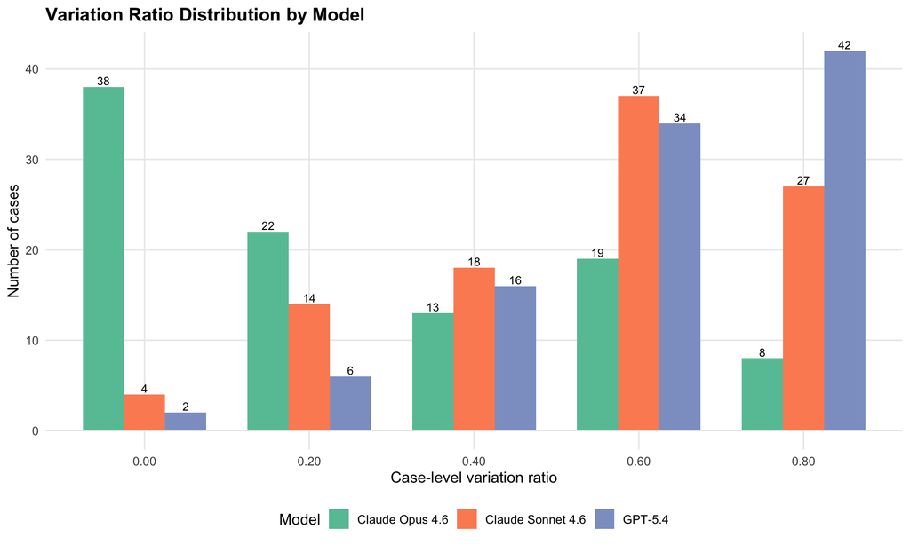

```r
theme_report <- theme_minimal(base_size = 12) +
  theme(
    plot.title = element_text(face = "bold"),
    panel.grid.minor = element_blank(),
    legend.position = "bottom"
  )

plot_variation_distribution <- variation_ratio_distribution %>%
  mutate(
    variation_ratio_label = factor(
      sprintf("%.2f", variation_ratio),
      levels = sprintf("%.2f", seq(0, 0.8, by = 0.2))
    )
  ) %>%
  ggplot(aes(x = variation_ratio_label, y = n_cases, fill = model_clean)) +
  geom_col(position = "dodge", width = 0.75) +
  geom_text(
    aes(label = n_cases),
    position = position_dodge(width = 0.75),
    vjust = -0.25,
    size = 3.2
  ) +
  scale_fill_brewer(palette = "Set2") +
  labs(
    title = "Variation Ratio Distribution by Model",
    x = "Case-level variation ratio",
    y = "Number of cases",
    fill = "Model"
  ) +
  theme_report

plot_model_summary <- model_summary %>%
  ggplot(
    aes(
      x = reorder(model_clean, mean_variation_ratio),
      y = mean_variation_ratio,
      fill = model_clean
    )
  ) +
  geom_col(width = 0.65, show.legend = FALSE) +
  geom_text(
    aes(label = sprintf("%.2f", mean_variation_ratio)),
    vjust = -0.25,
    size = 3.5
  ) +
  scale_y_continuous(labels = number_format(accuracy = 0.01)) +
  scale_fill_brewer(palette = "Set2") +
  labs(
    title = "Mean Intra-Model Variation Ratio",
    x = NULL,
    y = "Mean variation ratio"
  ) +
  theme_report

plot_exact_match <- model_summary %>%
  ggplot(
    aes(
      x = reorder(model_clean, exact_match_rate),
      y = exact_match_rate,
      fill = model_clean
    )
  ) +
  geom_col(width = 0.65, show.legend = FALSE) +
  geom_text(
    aes(label = percent(exact_match_rate, accuracy = 1)),
    vjust = -0.25,
    size = 3.5
  ) +
  scale_y_continuous(labels = percent_format()) +
  scale_fill_brewer(palette = "Set2") +
  labs(
    title = "Exact-Match Rate by Model",
    x = NULL,
    y = "Cases with all 5 repeated plans matching"
  ) +
  theme_report

plot_unstable_cases <- top_unstable_cases %>%
  mutate(case_id = fct_reorder(case_id, variation_ratio)) %>%
  ggplot(aes(x = variation_ratio, y = case_id, fill = model_clean)) +
  geom_col(show.legend = FALSE) +
  facet_wrap(~ model_clean, scales = "free_y") +
  scale_x_continuous(labels = number_format(accuracy = 0.1)) +
  scale_fill_brewer(palette = "Set2") +
  labs(
    title = "Top Unstable Cases by Model",
    x = "Variation ratio",
    y = "Case ID"
  ) +
  theme_report

plot_med_agreement <- medication_class_agreement %>%
  ggplot(aes(x = drug_class, y = model_clean, fill = active_agreement_rate)) +
  geom_tile(color = "white") +
  geom_text(aes(label = percent(active_agreement_rate, accuracy = 1)), size = 3) +
  scale_fill_gradient(low = "#f1a340", high = "#1b7837", labels = percent) +
  labs(
    title = "Active-Recommendation Agreement by Medication Class",
    x = "Medication class",
    y = "Model",
    fill = "Agreement"
  ) +
  theme_report +
  theme(axis.text.x = element_text(angle = 35, hjust = 1))

plot_action_agreement <- action_level_agreement %>%
  ggplot(
    aes(
      x = action_indicator,
      y = agreement_rate,
      fill = model_clean
    )
  ) +
  geom_col(position = "dodge", width = 0.75) +
  scale_y_continuous(labels = percent_format()) +
  scale_fill_brewer(palette = "Set2") +
  labs(
    title = "Action-Level Agreement by Model",
    x = "Parsed action indicator",
    y = "Agreement rate",
    fill = "Model"
  ) +
  theme_report +
  theme(axis.text.x = element_text(angle = 35, hjust = 1))

plot_alpha_sensitivity <- alpha_sensitivity_long %>%
  mutate(
    metric_definition = factor(
      metric_definition,
      levels = names(alpha_sensitivity_specs)
    ),
    model_label = case_when(
      model_clean == "Claude Opus 4.6" ~ "Claude Opus",
      model_clean == "Claude Sonnet 4.6" ~ "Claude Sonnet",
      model_clean == "GPT-5.4" ~ "GPT-5.4",
      TRUE ~ model_clean
    )
  ) %>%
  ggplot(
    aes(
      x = metric_definition,
      y = alpha,
      fill = model_label
    )
  ) +
  geom_col(position = "dodge", width = 0.75) +
  geom_text(
    aes(label = sprintf("%.3f", alpha)),
    position = position_dodge(width = 0.75),
    vjust = -0.25,
    size = 3.2
  ) +
  scale_y_continuous(
    limits = c(0, 1.05),
    labels = number_format(accuracy = 0.1)
  ) +
  scale_fill_brewer(palette = "Set2") +
  labs(
    title = "Krippendorff's Alpha Sensitivity Analysis",
    x = "Metric definition",
    y = "Krippendorff's alpha",
    fill = "Model"
  ) +
  theme_report +
  theme(axis.text.x = element_text(angle = 20, hjust = 1))

plot_medication_alpha <- medication_alpha_long %>%
  mutate(
    metric_definition = factor(
      metric_definition,
      levels = medication_alpha_specs
    ),
    model_label = case_when(
      model_clean == "Claude Opus 4.6" ~ "Claude Opus",
      model_clean == "Claude Sonnet 4.6" ~ "Claude Sonnet",
      model_clean == "GPT-5.4" ~ "GPT-5.4",
      TRUE ~ model_clean
    )
  ) %>%
  ggplot(
    aes(
      x = metric_definition,
      y = alpha,
      fill = model_label
    )
  ) +
  geom_col(position = "dodge", width = 0.75) +
  geom_text(
    aes(label = sprintf("%.3f", alpha)),
    position = position_dodge(width = 0.75),
    vjust = -0.25,
    size = 3.2
  ) +
  scale_y_continuous(
    limits = c(0, 1.05),
    labels = number_format(accuracy = 0.1)
  ) +
  scale_fill_brewer(palette = "Set2") +
  labs(
    title = "Medication-Column Dose-Level Alpha",
    x = "Metric definition",
    y = "Krippendorff's alpha",
    fill = "Model"
  ) +
  theme_report +
  theme(axis.text.x = element_text(angle = 20, hjust = 1))

ggsave(
  file.path(export_dir, "variation_ratio_distribution.png"),
  plot_variation_distribution,
  width = 10,
  height = 6,
  dpi = 300
)
ggsave(
  file.path(export_dir, "mean_variation_ratio_by_model.png"),
  plot_model_summary,
  width = 8,
  height = 5,
  dpi = 300
)
ggsave(
  file.path(export_dir, "exact_match_rate_by_model.png"),
  plot_exact_match,
  width = 8,
  height = 5,
  dpi = 300
)
ggsave(
  file.path(export_dir, "top_unstable_cases_by_model.png"),
  plot_unstable_cases,
  width = 10,
  height = 7,
  dpi = 300
)
ggsave(
  file.path(export_dir, "medication_class_agreement_heatmap.png"),
  plot_med_agreement,
  width = 10,
  height = 5,
  dpi = 300
)
ggsave(
  file.path(export_dir, "action_level_agreement_by_model.png"),
  plot_action_agreement,
  width = 11,
  height = 6,
  dpi = 300
)
ggsave(
  file.path(export_dir, "alpha_sensitivity_by_model.png"),
  plot_alpha_sensitivity,
  width = 10,
  height = 6,
  dpi = 300
)
ggsave(
  file.path(export_dir, "medication_column_alpha_by_model.png"),
  plot_medication_alpha,
  width = 10,
  height = 6,
  dpi = 300
)

plot_variation_distribution
```

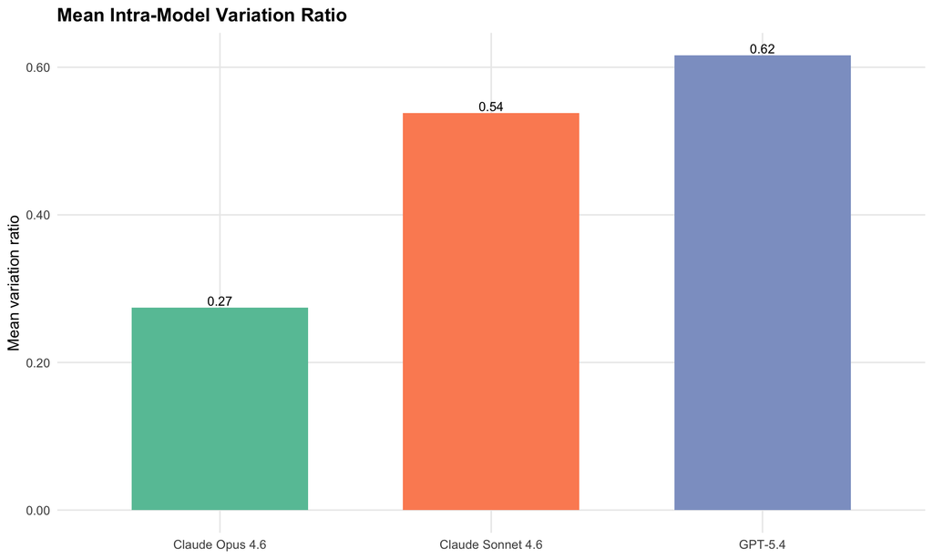

```r
plot_model_summary
```

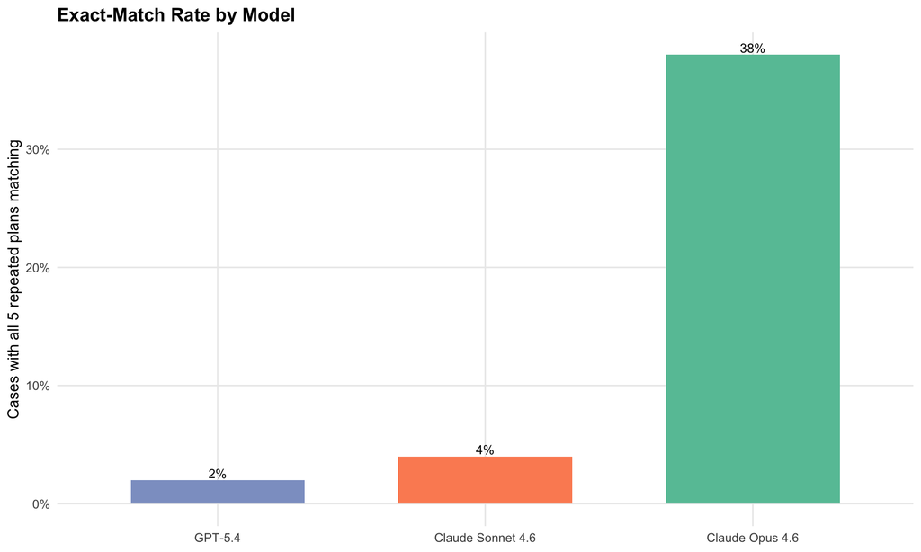

```r
plot_exact_match
```

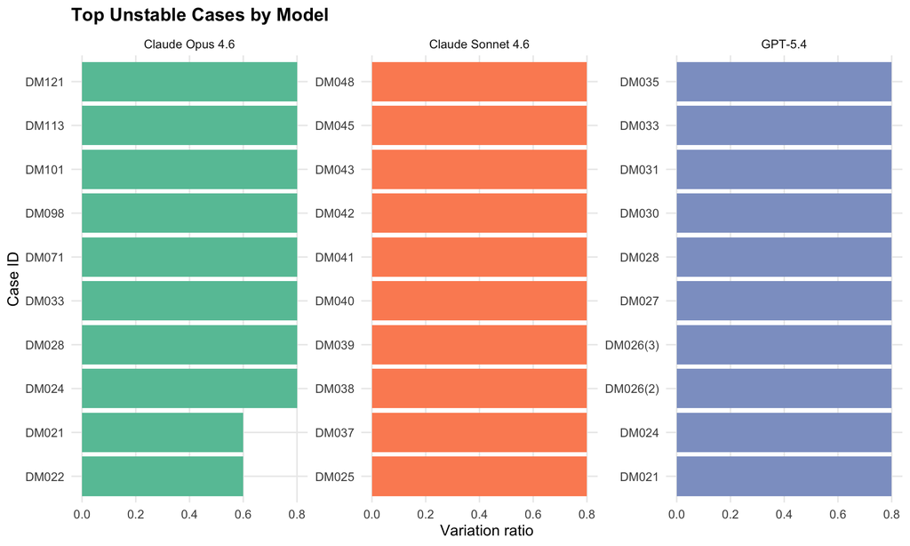

```r
plot_unstable_cases
```

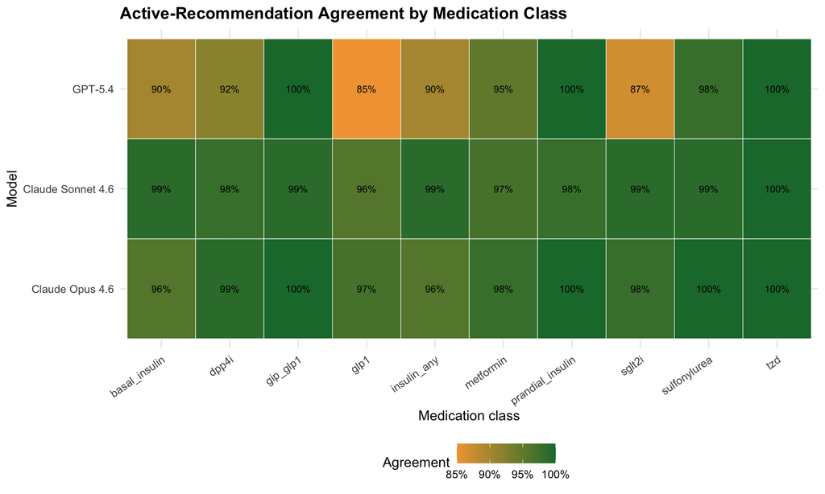

```r
plot_med_agreement
```

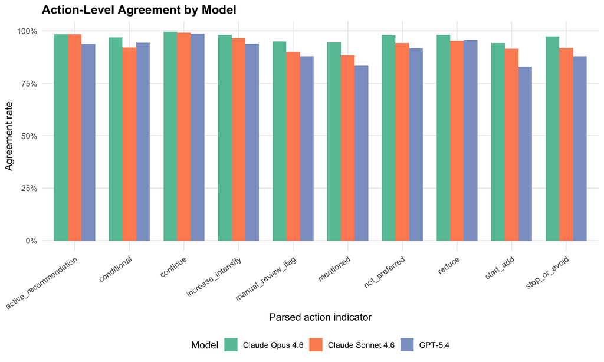

```r
plot_action_agreement
```

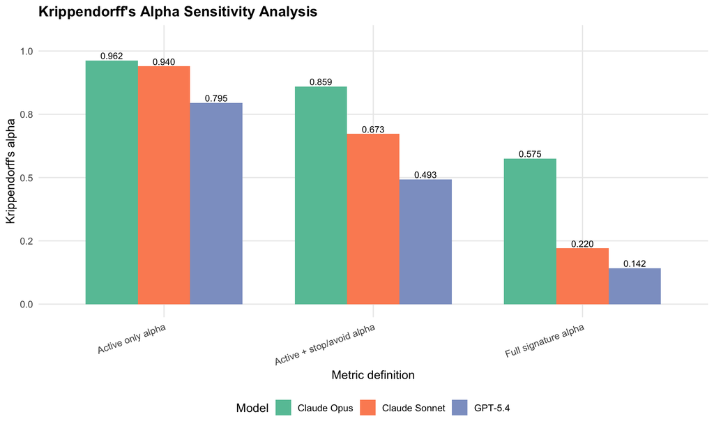

```r
plot_alpha_sensitivity
```

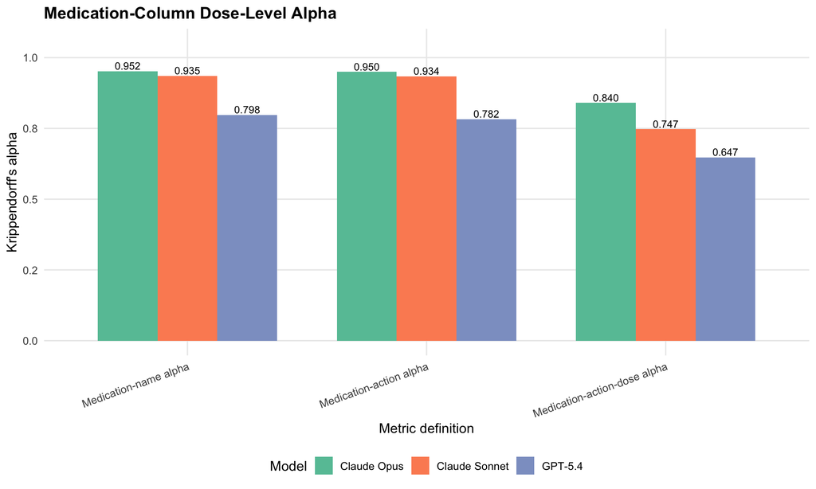

```r
plot_medication_alpha
```

# 12 Manual Review Sample

```r
manual_review_sample <- top_unstable_cases %>%
  select(model_clean, case_id, variation_ratio, n_unique_signatures) %>%
  left_join(
    treatment_signatures %>%
      select(
        model_clean,
        case_id,
        repeat_id,
        response_id,
        treatment_signature,
        n_active_classes,
        n_stop_avoid_classes,
        n_manual_review_classes
      ),
    by = c("model_clean", "case_id")
  ) %>%
  left_join(
    standardized %>%
      select(response_id, treatment_plan),
    by = "response_id"
  ) %>%
  arrange(model_clean, desc(variation_ratio), case_id, repeat_id)

write_csv(
  manual_review_sample,
  file.path(output_dir, "intra_model_manual_review_sample.csv")
)

manual_review_sample %>%
  select(
    model_clean,
    case_id,
    repeat_id,
    variation_ratio,
    n_active_classes,
    n_stop_avoid_classes,
    n_manual_review_classes
  ) %>%
  head(30) %>%
  kable(caption = "Manual review sample from unstable cases") %>%
  kable_styling(full_width = FALSE)
```

Manual review sample from unstable cases

| model_clean | case_id | repeat_id | variation_ratio | n_active_classes | n_stop_avoid_classes | n_manual_review_classes |
| --- | --- | --- | --- | --- | --- | --- |
| Claude Opus 4.6 | DM024 | 1 | 0.8 | 2 | 0 | 1 |
| Claude Opus 4.6 | DM024 | 2 | 0.8 | 2 | 0 | 0 |
| Claude Opus 4.6 | DM024 | 3 | 0.8 | 2 | 0 | 0 |
| Claude Opus 4.6 | DM024 | 4 | 0.8 | 2 | 0 | 0 |
| Claude Opus 4.6 | DM024 | 5 | 0.8 | 2 | 2 | 0 |
| Claude Opus 4.6 | DM028 | 1 | 0.8 | 2 | 0 | 0 |
| Claude Opus 4.6 | DM028 | 2 | 0.8 | 2 | 0 | 0 |
| Claude Opus 4.6 | DM028 | 3 | 0.8 | 2 | 0 | 1 |
| Claude Opus 4.6 | DM028 | 4 | 0.8 | 2 | 0 | 0 |
| Claude Opus 4.6 | DM028 | 5 | 0.8 | 2 | 1 | 0 |
| Claude Opus 4.6 | DM033 | 1 | 0.8 | 3 | 0 | 1 |
| Claude Opus 4.6 | DM033 | 2 | 0.8 | 3 | 1 | 1 |
| Claude Opus 4.6 | DM033 | 3 | 0.8 | 3 | 0 | 0 |
| Claude Opus 4.6 | DM033 | 4 | 0.8 | 3 | 0 | 1 |
| Claude Opus 4.6 | DM033 | 5 | 0.8 | 3 | 0 | 2 |
| Claude Opus 4.6 | DM071 | 1 | 0.8 | 2 | 0 | 0 |
| Claude Opus 4.6 | DM071 | 2 | 0.8 | 2 | 0 | 0 |
| Claude Opus 4.6 | DM071 | 3 | 0.8 | 2 | 0 | 0 |
| Claude Opus 4.6 | DM071 | 4 | 0.8 | 2 | 0 | 0 |
| Claude Opus 4.6 | DM071 | 5 | 0.8 | 2 | 0 | 0 |
| Claude Opus 4.6 | DM098 | 1 | 0.8 | 2 | 0 | 0 |
| Claude Opus 4.6 | DM098 | 2 | 0.8 | 2 | 0 | 1 |
| Claude Opus 4.6 | DM098 | 3 | 0.8 | 2 | 0 | 0 |
| Claude Opus 4.6 | DM098 | 4 | 0.8 | 2 | 0 | 0 |
| Claude Opus 4.6 | DM098 | 5 | 0.8 | 2 | 0 | 1 |
| Claude Opus 4.6 | DM101 | 1 | 0.8 | 2 | 2 | 0 |
| Claude Opus 4.6 | DM101 | 2 | 0.8 | 2 | 1 | 0 |
| Claude Opus 4.6 | DM101 | 3 | 0.8 | 2 | 1 | 0 |
| Claude Opus 4.6 | DM101 | 4 | 0.8 | 2 | 1 | 1 |
| Claude Opus 4.6 | DM101 | 5 | 0.8 | 2 | 0 | 0 |

# 13 Manuscript Exports

```r
make_export_table <- function(data) {
  flextable(data) %>%
    theme_booktabs() %>%
    autofit()
}

add_table_to_doc <- function(doc, title, data) {
  doc %>%
    body_add_par(title, style = "heading 2") %>%
    body_add_flextable(make_export_table(data)) %>%
    body_add_par("", style = "Normal")
}

model_summary_export <- model_summary %>%
  mutate(
    mean_variation_ratio = round(mean_variation_ratio, 3),
    median_variation_ratio = round(median_variation_ratio, 3),
    exact_match_rate = percent(exact_match_rate, accuracy = 0.1),
    krippendorff_alpha = round(krippendorff_alpha, 3)
  )

variation_ratio_distribution_export <- variation_ratio_distribution %>%
  mutate(percent_cases = percent(percent_cases, accuracy = 0.1))

alpha_by_model_export <- alpha_by_model %>%
  mutate(krippendorff_alpha = round(krippendorff_alpha, 3))

medication_class_agreement_export <- medication_class_agreement %>%
  mutate(
    mentioned_agreement_rate = percent(mentioned_agreement_rate, accuracy = 0.1),
    active_agreement_rate = percent(active_agreement_rate, accuracy = 0.1),
    stop_avoid_agreement_rate = percent(stop_avoid_agreement_rate, accuracy = 0.1)
  )

action_level_agreement_export <- action_level_agreement %>%
  mutate(agreement_rate = percent(agreement_rate, accuracy = 0.1))

manual_review_burden_export <- manual_review_burden %>%
  mutate(
    response_manual_review_rate = percent(
      response_manual_review_rate,
      accuracy = 0.1
    )
  )

manual_review_rate_by_instability_export <-
  manual_review_rate_by_instability %>%
  mutate(
    manual_review_response_rate = percent(
      manual_review_response_rate,
      accuracy = 0.1
    )
  )

medication_alpha_wide_export <- medication_alpha_wide

top_medication_dose_disagreement_export <-
  top_medication_dose_disagreement_cases %>%
  mutate(
    medication_dose_variation_ratio = round(
      medication_dose_variation_ratio,
      3
    )
  )

top_active_combinations_export <- active_treatment_combinations %>%
  select(
    model_clean,
    case_id,
    repeat_id,
    variation_ratio,
    n_unique_signatures,
    active_drug_classes
  ) %>%
  head(60)

targeted_review_examples_export <- targeted_review_examples

word_output_path <- file.path(
  export_dir,
  "intra_model_validation_tables.docx"
)

doc <- read_docx() %>%
  body_add_par("Intra-Model Validation Tables", style = "heading 1")

doc <- add_table_to_doc(doc, "Dataset overview", overview)
doc <- add_table_to_doc(doc, "Repeat-count validation", repeat_check)
doc <- add_table_to_doc(
  doc,
  "Model-level stability summary",
  model_summary_export
)
doc <- add_table_to_doc(
  doc,
  "Variation ratio distribution",
  variation_ratio_distribution_export
)
doc <- add_table_to_doc(
  doc,
  "Krippendorff's alpha",
  alpha_by_model_export
)
doc <- add_table_to_doc(
  doc,
  "Alpha sensitivity analysis",
  alpha_sensitivity_wide
)
doc <- add_table_to_doc(
  doc,
  "Medication-column alpha",
  medication_alpha_wide_export
)
doc <- add_table_to_doc(
  doc,
  "Top medication action-dose disagreement cases",
  top_medication_dose_disagreement_export
)
doc <- add_table_to_doc(
  doc,
  "Medication-class agreement",
  medication_class_agreement_export
)
doc <- add_table_to_doc(
  doc,
  "Action-level agreement",
  action_level_agreement_export
)
doc <- add_table_to_doc(
  doc,
  "Manual-review burden",
  manual_review_burden_export
)
doc <- add_table_to_doc(
  doc,
  "Max-unstable case counts",
  max_unstable_case_counts
)
doc <- add_table_to_doc(
  doc,
  "Manual-review burden by instability status",
  manual_review_rate_by_instability_export
)
doc <- add_table_to_doc(
  doc,
  "Manual-review flags by model and drug class",
  manual_review_by_model_drug %>% filter(manual_review_flags > 0)
)
doc <- add_table_to_doc(
  doc,
  "Manual-review flags by model and source",
  manual_review_by_model_source %>% filter(manual_review_flags > 0)
)
doc <- add_table_to_doc(
  doc,
  "Top unstable active-treatment combinations",
  top_active_combinations_export
)
doc <- add_table_to_doc(
  doc,
  "Representative parser-flagged rationale examples",
  targeted_review_examples_export
)

print(doc, target = word_output_path)

tibble(
  export_file = list.files(export_dir, full.names = FALSE)
) %>%
  arrange(export_file) %>%
  kable(caption = "Manuscript export files") %>%
  kable_styling(full_width = FALSE)
```

Manuscript export files

| export_file |
| --- |
| action_level_agreement_by_model.png |
| alpha_sensitivity_by_model.png |
| exact_match_rate_by_model.png |
| intra_model_validation_tables.docx |
| mean_variation_ratio_by_model.png |
| medication_class_agreement_heatmap.png |
| medication_column_alpha_by_model.png |
| top_unstable_cases_by_model.png |
| variation_ratio_distribution.png |

# 14 Output Files

```r
output_files <- tibble(
  file = list.files(output_dir, full.names = FALSE)
) %>%
  arrange(file)

output_files %>%
  kable(caption = "Files written by this workflow") %>%
  kable_styling(full_width = FALSE)
```

Files written by this workflow

| file |
| --- |
| intra_model_action_level_agreement.csv |
| intra_model_alpha_sensitivity_long.csv |
| intra_model_alpha_sensitivity_table.csv |
| intra_model_case_stability.csv |
| intra_model_krippendorff_alpha.csv |
| intra_model_manual_review_burden.csv |
| intra_model_manual_review_by_instability.csv |
| intra_model_manual_review_by_model_drug.csv |
| intra_model_manual_review_by_model_source.csv |
| intra_model_manual_review_sample.csv |
| intra_model_max_unstable_case_counts.csv |
| intra_model_medication_class_agreement.csv |
| intra_model_medication_column_alpha_long.csv |
| intra_model_medication_column_alpha_table.csv |
| intra_model_medication_column_parsed_long.csv |
| intra_model_medication_dose_case_stability.csv |
| intra_model_model_summary.csv |
| intra_model_parsed_long.csv |
| intra_model_parsed_wide.csv |
| intra_model_signature_counts.csv |
| intra_model_standardized_responses.csv |
| intra_model_targeted_review_examples.csv |
| intra_model_targeted_review_rows.csv |
| intra_model_top_medication_dose_disagreement_cases.csv |
| intra_model_top_unstable_active_combinations.csv |
| intra_model_top_unstable_cases.csv |
| intra_model_treatment_signatures.csv |
| intra_model_variation_ratio_distribution.csv |